# Analyzing the car information dataset

by Mugilan

2023-07-02

Loading libraries and the dataset:

```r
# Loading Libraries
library(tidyverse)
```

```r
library(lubridate)
library(dplyr)
library(ggplot2)
library(tidyr)
library(readr)

# Loading data
d <- read.csv('./Automobile.csv')
```

Taking a look at the data:

```r
head(d)
```

```
##                        name mpg cylinders displacement horsepower weight
## 1 chevrolet chevelle malibu  18         8          307        130   3504
## 2         buick skylark 320  15         8          350        165   3693
## 3        plymouth satellite  18         8          318        150   3436
## 4             amc rebel sst  16         8          304        150   3433
## 5               ford torino  17         8          302        140   3449
## 6          ford galaxie 500  15         8          429        198   4341
##   acceleration model_year origin
## 1         12.0         70    usa
## 2         11.5         70    usa
## 3         11.0         70    usa
## 4         12.0         70    usa
## 5         10.5         70    usa
## 6         10.0         70    usa
```

As we can see, there are 8 features (plus a name) for every car. Efficiency is quoted in MPG, or miles per gallon. We will now proceed to make a new feature (or column), converting MPG to KMPL (Kilometer Per Liter). 1 MPG = 0.425 KMPL

We shall also add a new feature called “hppt” which denotes the horsepower generated by the engine per 1000kg of vehicle mass. The calculation is: hp/t = (power * 1000)/weight

```r
d$Mileage <- d$mpg * 0.425
d$hppt <- (d$horsepower * 1000) / d$weight
head(d)
```

```
##                        name mpg cylinders displacement horsepower weight
## 1 chevrolet chevelle malibu  18         8          307        130   3504
## 2         buick skylark 320  15         8          350        165   3693
## 3        plymouth satellite  18         8          318        150   3436
## 4             amc rebel sst  16         8          304        150   3433
## 5               ford torino  17         8          302        140   3449
## 6          ford galaxie 500  15         8          429        198   4341
##   acceleration model_year origin Mileage     hppt
## 1         12.0         70    usa   7.650 37.10046
## 2         11.5         70    usa   6.375 44.67912
## 3         11.0         70    usa   7.650 43.65541
## 4         12.0         70    usa   6.800 43.69356
## 5         10.5         70    usa   7.225 40.59148
## 6         10.0         70    usa   6.375 45.61161
```

Now, let us visualize the data. Here are some interesting visualizations.

#### Histograms:

Power

Displacement

Mileage

#### Correlations:

hp/t to acceleration

displacement to horsepower

horsepower to mileage

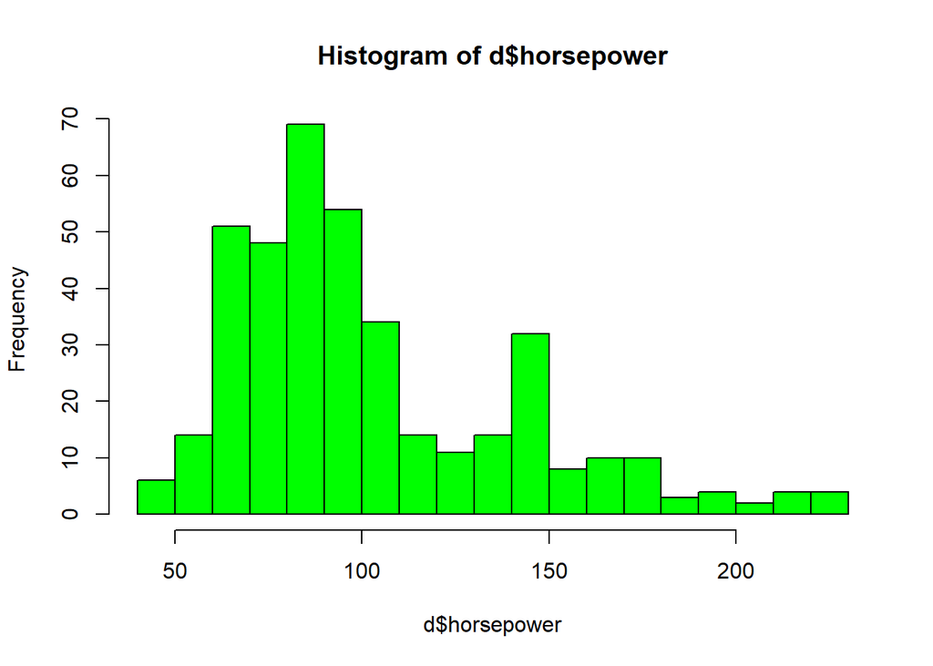

```r
hist(d$horsepower, col = "green", breaks = 20)
```

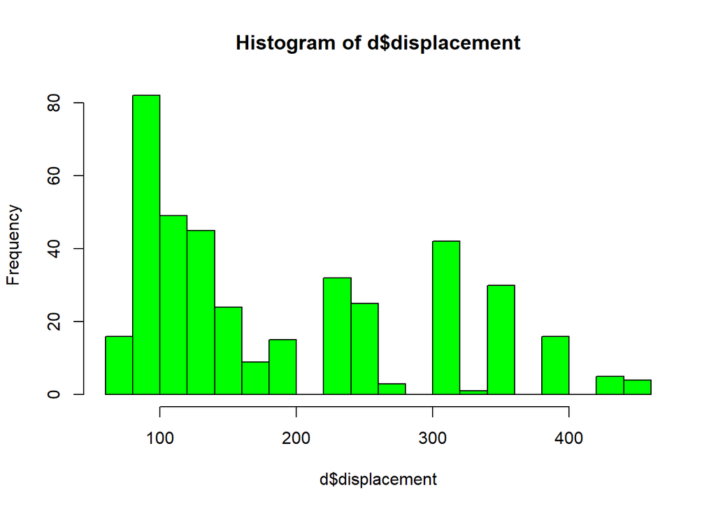

```r
hist(d$displacement, col = "green", breaks = 15)
```

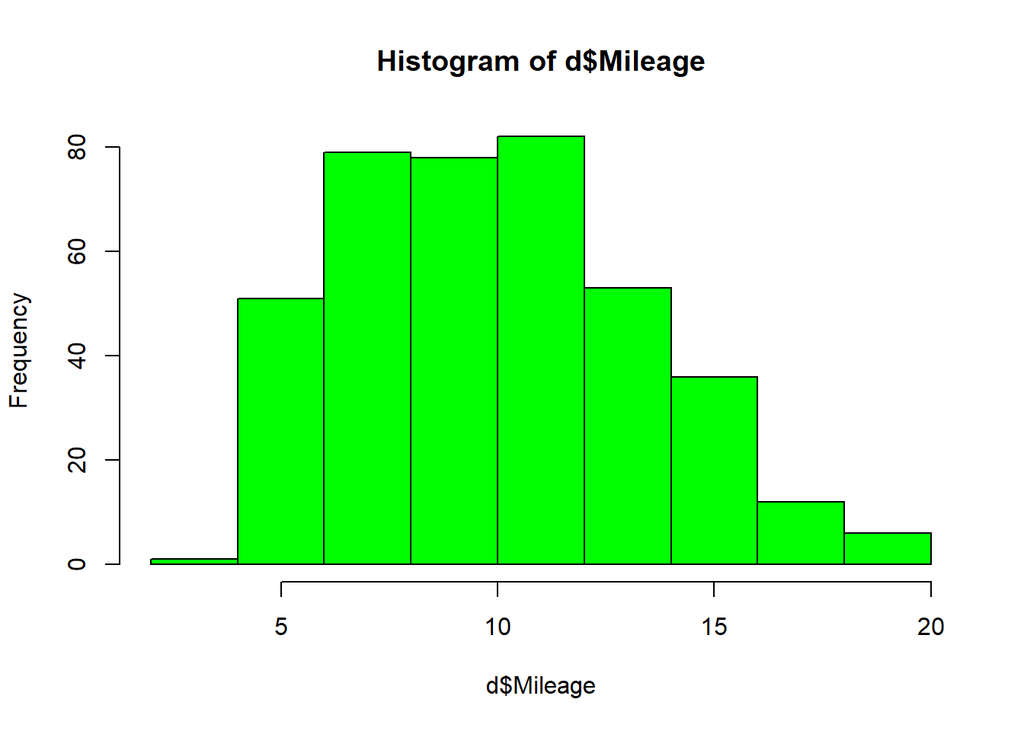

```r
hist(d$Mileage, col = "green")
```

#### Correlation plots:

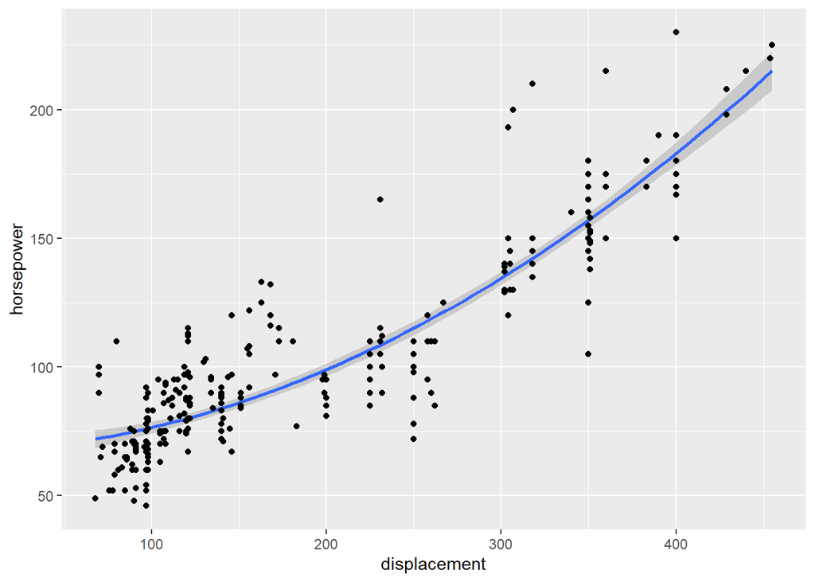

```r
ggplot(d, aes(x = displacement, y = horsepower)) + geom_smooth(method=lm, formula = y ~ poly(x, 2)) + geom_point()
```

```r
cor(d$displacement, d$horsepower, use = "complete.obs")
```

```
## [1] 0.897257
```

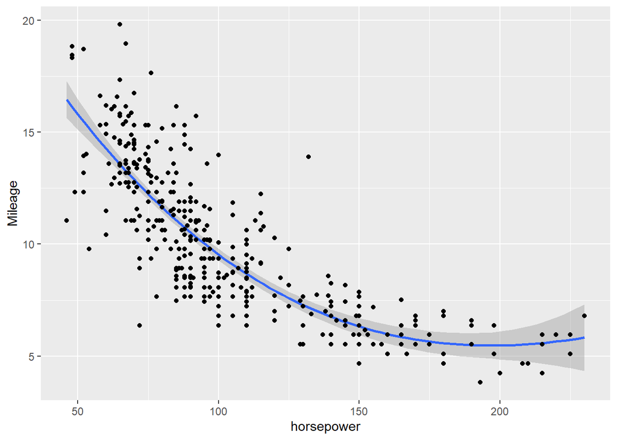

```r
ggplot(d, aes(x = horsepower, y = Mileage)) + geom_smooth(method = lm, formula = y ~ poly(x, 3)) + geom_point()
```

```r
cor(d$horsepower, d$Mileage, use = "complete.obs")
```

```
## [1] -0.7784268
```

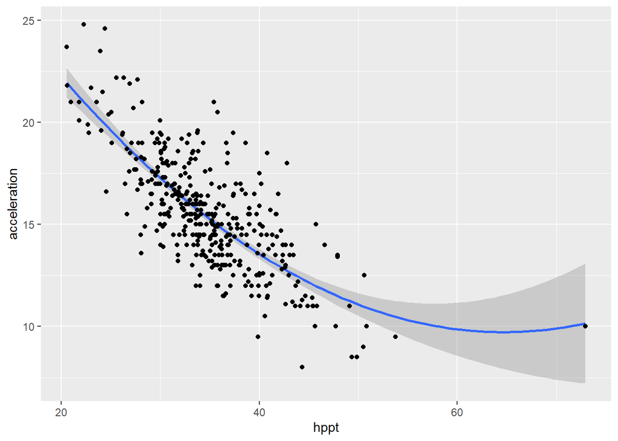

```r
ggplot(d, aes(x = hppt, y = acceleration)) + geom_smooth(method = lm, formula = y ~ poly(x, 2)) + geom_point()
```

```r
cor(d$hppt, d$acceleration, use = "complete.obs")
```

```
## [1] -0.7350658
```

In the HPPT feature, there is a unique outlier. Let us find it, then remove it for plotting the hppt/acceleration correlation.

```r
d[which.max(d$hppt),]
```

```
##                       name mpg cylinders displacement horsepower weight
## 14 buick estate wagon (sw)  14         8          455        225   3086
##    acceleration model_year origin Mileage     hppt
## 14           10         70    usa    5.95 72.90992
```

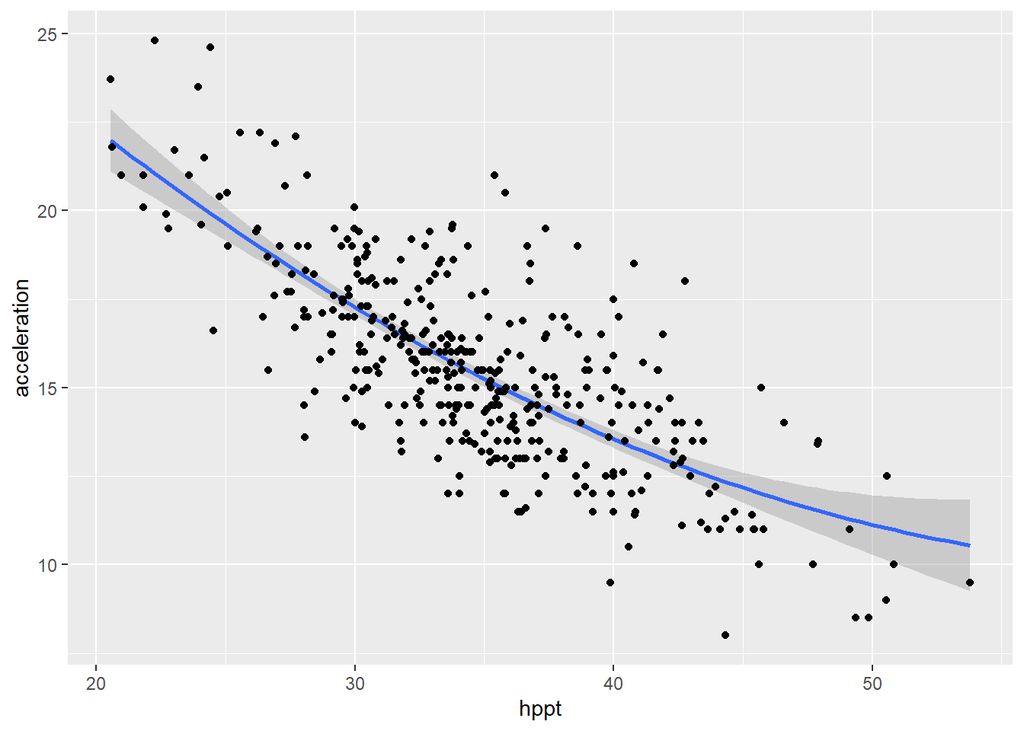

```r
d2 <- data.frame(d)
d2 <- subset(d2, hppt < 70)

ggplot(d2, aes(x = hppt, y = acceleration)) + geom_smooth(method = lm, formula = y ~ poly(x, 2)) + geom_point()
```

```r
cor(d2$hppt, d2$acceleration, use = "complete.obs")
```

```
## [1] -0.7461596
```

Let us now calculate the mean of hp, displacement and mileage for more insights.

```r
mean(d$displacement)
```

```
## [1] 193.4259
```

```r
mean(d$Mileage)
```

```
## [1] 9.993693
```

```r
mean(d$horsepower)
```

```
## [1] NA
```

```r
mean(d$horsepower, na.rm=TRUE)
```

```
## [1] 104.4694
```

## Results of analysis:

The mean displacement is 193 cubic inches, or about 3.2 Liters. The mean Mileage is about 10 km/L. Mean horsepower is about 105hp.

There is significant sampling bias. These are very old sport cars, ranging from 1970 models to 1982 models. It is clearly noticeable considering the very high mean displacement but with (today’s) average horsepower.

Regarding correlations, a negative correlation (-0.78) can be found between Mileage and hp. A strong positive correlation (0.89) is found between horsepower and displacement. The “acceleration” attribute is the 0-100mph time, therefore a smaller value means faster. This is correlated with hp/t, or the thrust-weight ratio of the car (0.75).